# Lab #1: Push Something Around

This exercise will take one week. It’s time to control the world, one motor at a time, Python style.

## Control a Physical Thing

An efficient way to control the torque in a DC motor or brightness of an LED is pulse width modulation. Pulse width modulation uses a square wave of varying *duty cycle* (the fraction of time a signal is on) to modulate the average voltage. In the drawing below, a voltage of *V<sub>M</sub>* delivers full voltage to a motor and 0 volts delivers zero net voltage, so as the PWM duty cycle changes from about 40% to about 80%, it causes an increase in motor torque, assuming roughly constant motor speed.

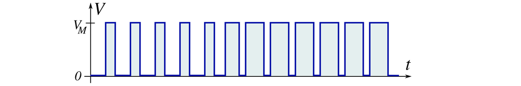

Most microcontrollers contain timer/counter hardware which, when configured properly, creates square waves with controllable duty cycles. Once the hardware has been configured correctly, you just have to tell it the percentage of time the signal should be on as a fraction (or percentage) of the wave period, and the hardware will keep sending that wave until told to do otherwise.

We’ll begin by writing a program which uses PWM to control the brightness of an LED (mostly review from Lab 0); then we’ll use it to control a motor.

- Connect an LED through a 220Ω – 330Ω resistor to the `3V3` pin and pin `PA0` on the Nucleo. You can use the `GND` and `3V3` pins to check which way the LED and resistor must be connected so it lights (the LED is a diode, so only one way will work). **Never** connect an LED without a **current limiting resistor** in series.
- Set pin `PA0` as an output and verify that you can turn the LED on and off.
- Modify the PWM code you’ve tried in Lab 0 to control the LED’s brightness. You need to look on the **STM32L476RG Nucleo Arduino Pins** diagram on Canvas to see which timer and channel must be used. The purple boxes showing `PWMx/y` numbers indicate that you must use Timer `x` and Channel `y` for a given pin.

  Because the LED will be **on** when the PWM signal is a logic **zero,** you must set the timer channel to mode `pyb.Timer.PWM_INVERTED` to control LED brightness.
- Copy your code into Thonny’s editor window to make a script that you can run. Test your code by running it several times and verifying that it works. Save the file you’re writing in your `src` directory as `led.py`.
- Write two functions called `led_setup()` and `led_brightness()` in your file. The setup function should prepare the PWM timer and channel, and the brightness function should set the PWM duty cycle.

  Each function should be commented with Doxygen style comments. See the file **the_answer.py** on Canvas for an example of how your Doxygen comments should be formatted.
- Write a script in `led.py` which calls the functions repeatedly in a loop to make the LED’s brightness slowly increase from 0 to maximum over 5 seconds, then go back to 0 and repeat the process indefinitely until someone cuts off the Nucleo’s power or presses Ctrl-C. The script should be below the functions, with the file following the format below:

  ```python
  """! @file led.py
  Doxygen style docstring for the file (change this!)"""

  def led_setup ():
      """! Doxygen style docstring for this function """
      Function code here

  def led_brightness ():
      """! Doxygen style docstring for this function """
      More function code here

  if __name__ == "__main__":
      Script code goes here
  ```

## Motor Control

Your ME405 kit includes an L6206 motor driver “shield”, a circuit board which can be attached atop the Nucleo and used to control two DC motors. It has a dual **H-Bridge** chip which can control the magnitude and direction of the torque produced by each of two motors.

An H-bridge motor driver has logic inputs to control which transistors in the bridge are turned on at any given time and to ensure that the two transistors in each half-bridge are never turned on at the same time, as this would short power to ground and let lots of smoke out. An excerpt from the L6206 motor driver IC’s datasheet is shown below:

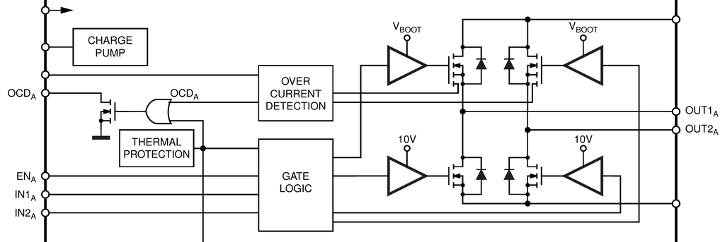

One of the chip’s two H-bridges consists of the four N-channel FET’s in the right half of the diagram, with the motor connected to pins **OUT1A** and **OUT2A**. The microcontroller controls pins **ENA**, **IN1A**, and **IN2A**. A common way of using these pins is to set **ENA** high to enable the motor, set **IN1A** low, and send a PWM signal to **IN2A** to power the motor in one direction; reverse the signals to **IN1A** and **IN2A** to power the motor in the other direction. A truth table in the L6206 datasheet specifies the logic between these pins and what the chip does to the motor.

| L6206 Pin | CPU Pin | Timer | Ch. |  |  |  |  |  | L6206 Pin | CPU Pin | Timer | Ch. |
| --- | --- | --- | --- | --- | --- | --- | --- | --- | --- | --- | --- | --- |
| EN<sub>A</sub>/OCD<sub>A</sub> | PA10 | - | - |  |  |  |  |  | EN<sub>B</sub>/OCD<sub>B</sub> | PC1 | - | - |
| IN1<sub>A</sub> | PB4 | TIM3 | 1 |  |  |  |  |  | IN1<sub>B</sub> | PA0 | TIM5 | 1 |
| IN2<sub>A</sub> | PB5 | TIM3 | 2 |  |  |  |  |  | IN2<sub>B</sub> | PA1 | TIM5 | 2 |

The table above shows the connections between the logic input pins on the L6206 and the CPU pins on the Nucleo motor control expansion board. The **ENx** and **OCDx** pins are connected together on the motor driver board, so it is best to set up the microcontroller pins connected to **ENx**/**OCDx** as open-drain outputs with pullup resistors enabled so that the microcontroller can read the pins to detect motor driver problems. The **INn<sub>x</sub>** pins can be set up as regular push-pull outputs.

## Motor Control Procedure

- Disconnect the USB cable from your MicroPython board to turn off its power. Attach a blue IHM04A1 motor driver board atop the Nucleo. Connect a DC motor to the Motor A screw terminals on the driver board with the orange and green wires which are twisted together (if they have become un-twisted, twist them loosely back together). Use the long red and black twisted pair wire from your kit to connect power from a benchtop supply to the motor driver board’s **GND** and **Vin** screw terminals.

  Double-check that only the orange and green motor leads are connected from your motor to the motor driver board. Re-attach the USB cable to the Nucleo and power the motor driver with 12 volts and a 0.5 amp current limit.
- Now use what you have learned so far to write code that makes the motor run in each direction and stop. It is recommended to use *two* PWM channels, one for each **INnA** pin on the motor driver chip: to push the motor in one direction, set **IN1A** to 0% duty cycle and use **IN2A** other to control torque; to push the other way, set **IN2A** to 0% and use **IN1A** for control.

  *Note:* Unlike LEDs, the motor drivers use regular non-inverted PWM logic, so set up your timer channels in mode `pyb.Timer.PWM` mode, not `PWM_INVERTED` mode.

## A Touch of Class

You’ll be using motor and encoder drivers for projects throughout this course, so it will save time to write them as classes. You should write a motor driver class which drives one motor; to use two motors, you can create two objects from that class.

#### Motor Driver Class

- Write a motor driver class called `MotorDriver` in a file called `motor_driver.py`. The constructor `__init__()` should set up pins to control the motor, and a method called `set_duty_cycle()` should set the duty cycle and direction of the motor power voltage. The class and each method must have a docstring that describes what it does and how to use it, and each parameter (except `self`) must have a `@param` descriptor. A template for the class is below.

  ```python
  class MotorDriver:
      """!
      This class implements a motor driver for an ME405 kit.
      """

      def __init__ (self, en_pin, in1pin, in2pin, timer):
          """!
          Creates a motor driver by initializing GPIO
          pins and turning off the motor for safety.
          @param en_pin (There will be several parameters)
          """
          print ("Creating a motor driver")

      def set_duty_cycle (self, level):
          """!
          This method sets the duty cycle to be sent
          to the motor to the given level. Positive values
          cause torque in one direction, negative values
          in the opposite direction.
          @param level A signed integer holding the duty
                 cycle of the voltage sent to the motor
          """
          print (f"Setting duty cycle to {level}")
  ```

- Test your `MotorDriver` with code such as the following:

  ```python
  moe = MotorDriver (a_pin, another_pin, a_timer)
  moe.set_duty_cycle (-42)
  ```

- Write test code in `motor_driver.py` which exercises your motor driver and exorcises any bugs. It should be in an `if __name__ == '__main__'` block at the bottom of the file to allow you to do the next step easily.
- Verify that you can `import motor_driver.py` and operate the motor from the REPL by using your motor controller class. This is done by uploading `motor_driver.py` to the Nucleo, then writing and running a short main file which uses the motor driver to run the motor in a sequence of motions, slow and fast, in both directions as well as stopped.

### Testing

- Test your motor driver class by sending it a range of duty cycles, both positive and negative, and checking that the motor moves both ways. Make sure to check “edge cases” such as the maximum and minimum possible duty cycles for proper operation.
- Write test code in blocks with `if __name__ == "__main__"` in your module file.

## Deliverables

#### In Lab Today

- Demonstrate your basic PWM program running on an LED. If for some reason you’re not able to make the program run during the lab session, you may submit a video for this assignment.
- Ideally, get a motor running and demonstrate that also.

#### By the Beginning of Next Week’s Lab

- Make a new `Lab 1` repository on GitHub™ and upload your source and documentation there.
  - The file `motor_driver.py`, will be imported into a test program written by the grader for testing.
- Remember to set up the GitHub Pages™ site to host your Doxygen documents on the Interwebs.
- Submit the URLs of your source *and* documentation sites on Cantvas. If you’ve made a video (usually not needed), you may submit the URL of that also.